# Microtools and the reader monad for resource dependency injection

Dror Speiser

This is a command that I run daily on the cloud:

```
bashit nohup sshd&; dasker '{"nworkers": 36}' \
  shirker secret://slack.token -- make_all_the_money
```

Here's a breakdown:

| code | what it does |
| --- | --- |
| `bashit nohup sshd&;` | interactive monitoring |
| `dasker '{...}'` | cluster |
| `shirker secret://...` | logging |
| `make_all_the_money` | business logic |

We'll go over these one by one, from the bottom up

# `make_all_the_money`

## I will not be presenting `make_all_the_money`.

# shirker

someone who avoids something, especially work: We have no room for shirkers in this office.

Synonym. **slacker**

(pypi.org/slacker was taken)

How to log in python?

I googled it, here's what came up:

1. print
2. logging module
3. ElasticSearch
4. Slack api
5. Twiggy, logbook, ...

| method | what it needs |
| --- | --- |
| print | nothing |
| logging module | single import |
| ElasticSearch | package dependency + 5 lines |
| Slack api | package dependency + ? lines |
| Twiggy, logbook, ... | package dependency + ? lines |

Some points about MATM

1. It's not related to ElasticSearch

Some points about MATM

1. It's not related to ElasticSearch
2. I didn't write it - I don't want to change it

Some points about MATM

1. It's not related to ElasticSearch
2. I didn't write it - I don't want to change it
3. I run it locally and in tests - no logging please

Some points about MATM

1. It's not related to ElasticSearch
2. I didn't write it - I don't want to change it
3. I run it locally and in tests - no logging please
4. Thoughts on rewriting in Rust

Some points about me

1. I actually like ELK and Slack

# print/logging module

When I run MATM in a terminal, *I see* the messages

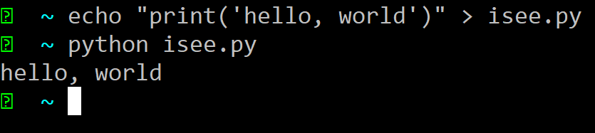

If *I* see the messages, can I pass them on to Slack or ES?

Yes. I run on linux, and on linux every process gets two "files":

- stdout
- stderr

The default in a terminal is to write both to the screen

But they don't have to be

## what shirker does

`shirker secret://slack.token -- make_all_the_money`

1. reads secret token
2. sends a slack message "starting to run `make_all_the_money`"
3. actually runs `make_all_the_money`, saving the stdout and stderr
4. uploads the stdout and stderr in replies to the first message

# shirker - disadvantages

- adds a process
- not perfomant logging
- not fine grained
- I have to remember to use it
- can lose some orderding

# shirker - advantages

- I didn't touch my business app at all
- It's easy to turn it on and off
- Code reuse for all apps in any language
- Doesn't have to be a dependency

And I distribute shirker on pypi.org

# dasker

someone who uses dask? dask is a package for parallel computing in python.

No synonyms.

(pypi.org/dasker was free)

## clusters

Generally clusters have three types of components: **Clients**, a **Scheduler**, and **Workers**

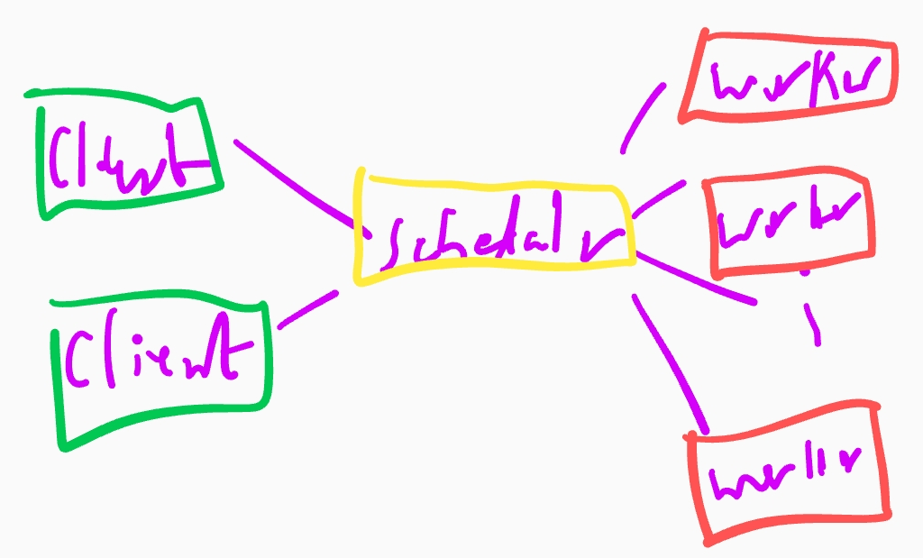

Some points about MATM

- It usually does well with 36 vCPUs and 64GB RAM
- Sometimes it's better to run with 96 vCPUS and 500GB RAM
- I want to run it locally and in tests
- Sometimes I think it will need 36 vCPUS, and then realize it needs 1000
- Would rather not change it
- Definitely don't want to put interesting cluster logic in it
- I would be happy to configure cluster where I configure what I'm running

Existing solutions:

- Dask + Coiled
- Ray + cloud/k8s
- Spark + AWS EMR
- Spark + Databricks

These actually work pretty well, but suffer two major problems:

1. Can't natively run locally or in tests
2. Cluster always has a predefined maximum size

# what dasker does

`dasker '{"nworkers": 36}' app arg1 arg2 ...`

1. Either starts a local cluster, or connects to one
2. Sets an environment variables with the scheduler's address
3. Runs the `app arg1 arg2 ...`

## changes in MATM

1. use `dasker.get_client()`

   i. reads environment variable

   ii. connects to scheduler

** This can be easily made to work with Ray or Spark as well

Advantages:

1. MATM is not responsible for setting compute resources
2. Easy to run locally and in tests
3. Infinite scalability - just connect more machines

Like shirker, I distribute on pypi

# bashit nohup sshd&;

- bashit is a tiny tool that puts all the arguments in a file and run it with bash
- sshd - starts an ssh server so that I can connect and have fun on the machine

# shirker and dasker

What do they have in common?

1. Small packages on pypi
2. Responsible for a single resource
3. Composable

# composable?

Say I run `shirker app1`

And `app1` starts `app2`

`app2` uses the stdout and stderr of `app1`, which is the same as `shirker`

So we get slack logging in `app2` for free

The same is true for `dasker`

Next time you create an application `app1`, ask yourself:

What if someone starts `app2`?

Thank you for listening!

Questions?